# Motor Trend analysis: Automatic or manual transmission?

Daria Stepanyan

## Exploratory analysis

```r
data(mtcars)
str(mtcars)
```

```
## 'data.frame':    32 obs. of  11 variables:
##  $ mpg : num  21 21 22.8 21.4 18.7 18.1 14.3 24.4 22.8 19.2 ...
##  $ cyl : num  6 6 4 6 8 6 8 4 4 6 ...
##  $ disp: num  160 160 108 258 360 ...
##  $ hp  : num  110 110 93 110 175 105 245 62 95 123 ...
##  $ drat: num  3.9 3.9 3.85 3.08 3.15 2.76 3.21 3.69 3.92 3.92 ...
##  $ wt  : num  2.62 2.88 2.32 3.21 3.44 ...
##  $ qsec: num  16.5 17 18.6 19.4 17 ...
##  $ vs  : num  0 0 1 1 0 1 0 1 1 1 ...
##  $ am  : num  1 1 1 0 0 0 0 0 0 0 ...
##  $ gear: num  4 4 4 3 3 3 3 4 4 4 ...
##  $ carb: num  4 4 1 1 2 1 4 2 2 4 ...
```

The data was extracted from the 1974 Motor Trend US magazine, and comprises fuel consumption and 10 aspects of automobile design and performance for 32 automobiles (1973-74 models). Dataset description can be found here: https://stat.ethz.ch/R-manual/R-devel/library/datasets/html/mtcars.html

Let’s take a look at the rest of the variables relations to mpg.

```r
cor(mtcars$mpg,mtcars[,-1])
```

```
##            cyl       disp         hp      drat         wt     qsec
## [1,] -0.852162 -0.8475514 -0.7761684 0.6811719 -0.8676594 0.418684
##             vs        am      gear       carb
## [1,] 0.6640389 0.5998324 0.4802848 -0.5509251
```

From the correlation results, we can see, that the cyl, hp, wt and carb are negatively correlated with mpg.

Transmission data is stored in variable “am” (0 = automatic, 1 = manual). For easier interpreptation, let’s convert it to the factor variable (along with the cylinders number)

```r
mtcars$am <- factor(mtcars$am,labels=c('Automatic','Manual'))
mtcars$cyl <- factor(mtcars$cyl)
```

The boxplot (appendix 1) shows that cars with manual transmission have better mpg (can go more distance on the same amount of gas). When plotting the data across different cylinders amount though, the result is not as straigntforward (Appendix 2).

## Regression analysis

Let’s see how much of the variance in mpg is actually explained by transmission type.

```r
summary(lm(mpg~ am,data=mtcars))$r.squared
```

```
## [1] 0.3597989
```

While manual transmission cars seem to have more mpg on average, with this variability we can’t say that transmission type is the only influencing parameter. This needs to be further explored in a multiple linear regression analysis.

We use the step function in R for a stepwise regression, where the choice of predictor is carried out automatically.

```r
best = step(lm(data = mtcars, mpg ~ .),trace=0)
best$call
```

```
## lm(formula = mpg ~ wt + qsec + am, data = mtcars)
```

```r
summary(best)$r.squared
```

```
## [1] 0.8496636
```

Interestingly, the qsec is chosen as a defining parameter, since it clearly depends on car’s design and such parameters as horse power and number of cylinders. Let’s see if the model will be better fitted if we use those instead of their dependant, qsec.

```r
final <- lm(mpg~ am+wt+hp+cyl,data=mtcars)
summary(final)$r.squared
```

[output not shown]

This model explains almost the same amount of variance in mpg, but is way easier for interpretation, so let’s assume it as our final model.

```r
summary(final)$coefficients
```

[output not shown]

We can see that with all other parameters being equal manual transmission increases mpg by 1.4780477. Residuals (see Appendix 3) are also randomly scattered.

## Inference

However with 95% confidence we can’t say that manual transmission always has a positive effect on mpg, so the influence of transmission type is not statistically sinificant.

```r
confint(final, 'amManual')
```

```
##              2.5 %   97.5 %
## amManual -1.478946 4.435042
```

We can also check if our model is significant, in other words is a better fitted than a model with just am as predictor.

```r
anova(lm(mpg~ am,data=mtcars), final)
```

[output not shown]

As the p-value is significant, we reject the null hypothesis that the models are similar and conclude that the additional variables in our final model are necessary.

# Appendix

## Apendix 1. Boxplot of mpg per transmission type

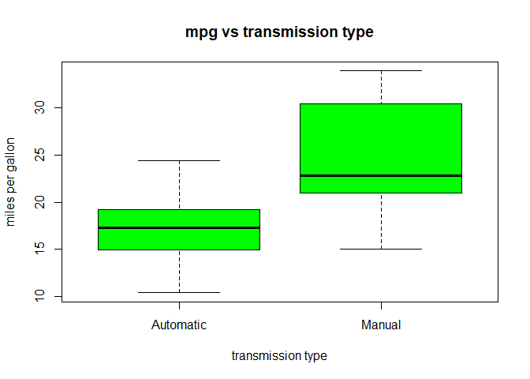

```r
boxplot(mtcars$mpg ~ mtcars$am, data = mtcars,
        ylab="miles per gallon",
        xlab="transmission type",
        main="mpg vs transmission type",
        col="green")
```

## Appendix 2. Boxplot of mpg per transmission type per cylinder

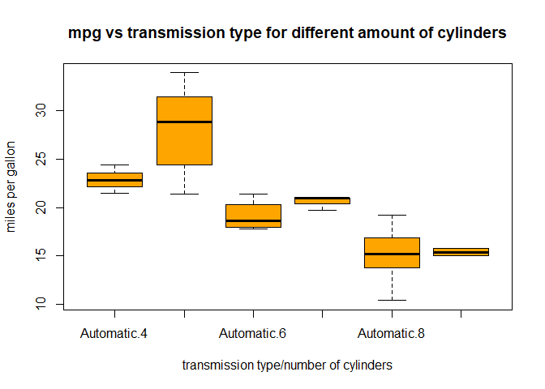

```r
boxplot(mtcars$mpg ~mtcars$am + mtcars$cyl, data = mtcars,
        ylab="miles per gallon",
        xlab="transmission type/number of cylinders",
        main="mpg vs transmission type for different amount of cylinders",
        col="orange")
```

## Appendix 3. Residuals

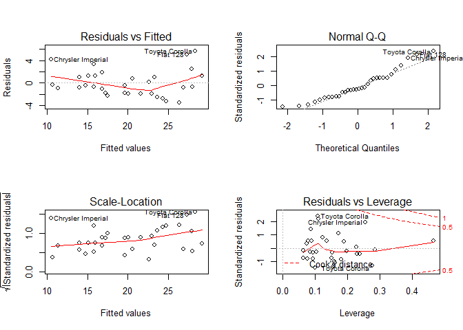

```r
par(mfrow=c(2,2))
plot(final)
```